# website1

|  | Index | UsingIP | LongURL | ShortURL | Symbol@ | Redirecting// | PrefixSuffix- | SubDomains | HTTPS | DomainRegLen | ... | UsingPopupWindow | IframeRedirection | AgeofDomain | DNSRecording | WebsiteTraffic | PageRank | GoogleIndex | LinksPointingToPage | StatsReport | class |
| --- | --- | --- | --- | --- | --- | --- | --- | --- | --- | --- | --- | --- | --- | --- | --- | --- | --- | --- | --- | --- | --- |
| 0 | 0 | 1 | 1 | 1 | 1 | 1 | -1 | 0 | 1 | -1 | ... | 1 | 1 | -1 | -1 | 0 | -1 | 1 | 1 | 1 | -1 |
| 1 | 1 | 1 | 0 | 1 | 1 | 1 | -1 | -1 | -1 | -1 | ... | 1 | 1 | 1 | -1 | 1 | -1 | 1 | 0 | -1 | -1 |
| 2 | 2 | 1 | 0 | 1 | 1 | 1 | -1 | -1 | -1 | 1 | ... | 1 | 1 | -1 | -1 | 1 | -1 | 1 | -1 | 1 | -1 |
| 3 | 3 | 1 | 0 | -1 | 1 | 1 | -1 | 1 | 1 | -1 | ... | -1 | 1 | -1 | -1 | 0 | -1 | 1 | 1 | 1 | 1 |
| 4 | 4 | -1 | 0 | -1 | 1 | -1 | -1 | 1 | 1 | -1 | ... | 1 | 1 | 1 | 1 | 1 | -1 | 1 | -1 | -1 | 1 |

5 rows × 32 columns

## 2. Familiarizing with Data & EDA:

In this step, few dataframe methods are used to look into the data and its features.

```
Index(['Index', 'UsingIP', 'LongURL', 'ShortURL', 'Symbol@', 'Redirecting//',
       'PrefixSuffix-', 'SubDomains', 'HTTPS', 'DomainRegLen', 'Favicon',
       'NonStdPort', 'HTTPSDomainURL', 'RequestURL', 'AnchorURL',
       'LinksInScriptTags', 'ServerFormHandler', 'InfoEmail', 'AbnormalURL',
       'WebsiteForwarding', 'StatusBarCust', 'DisableRightClick',
       'UsingPopupWindow', 'IframeRedirection', 'AgeofDomain', 'DNSRecording',
       'WebsiteTraffic', 'PageRank', 'GoogleIndex', 'LinksPointingToPage',
       'StatsReport', 'class'],
      dtype='object')
```

```
<class 'pandas.core.frame.DataFrame'>
RangeIndex: 11054 entries, 0 to 11053
Data columns (total 32 columns):
 #   Column               Non-Null Count  Dtype
---  ------               --------------  -----
 0   Index                11054 non-null  int64
 1   UsingIP              11054 non-null  int64
 2   LongURL              11054 non-null  int64
 3   ShortURL             11054 non-null  int64
 4   Symbol@              11054 non-null  int64
 5   Redirecting//        11054 non-null  int64
 6   PrefixSuffix-        11054 non-null  int64
 7   SubDomains           11054 non-null  int64
 8   HTTPS                11054 non-null  int64
 9   DomainRegLen         11054 non-null  int64
```

[output cut: 24 more lines]

```
Index                  11054
UsingIP                    2
LongURL                    3
ShortURL                   2
Symbol@                    2
Redirecting//              2
PrefixSuffix-              2
SubDomains                 3
HTTPS                      3
DomainRegLen               2
Favicon                    2
NonStdPort                 2
HTTPSDomainURL             2
RequestURL                 2
AnchorURL                  3
LinksInScriptTags          3
ServerFormHandler          3
InfoEmail                  2
AbnormalURL                2
WebsiteForwarding          2
StatusBarCust              2
DisableRightClick          2
UsingPopupWindow           2
IframeRedirection          2
AgeofDomain                2
DNSRecording               2
WebsiteTraffic             3
PageRank                   2
GoogleIndex                2
LinksPointingToPage        3
StatsReport                2
class                      2
dtype: int64
```

|  | count | mean | std | min | 25% | 50% | 75% | max |
| --- | --- | --- | --- | --- | --- | --- | --- | --- |
| UsingIP | 11054.0 | 0.313914 | 0.949495 | -1.0 | -1.0 | 1.0 | 1.0 | 1.0 |
| LongURL | 11054.0 | -0.633345 | 0.765973 | -1.0 | -1.0 | -1.0 | -1.0 | 1.0 |
| ShortURL | 11054.0 | 0.738737 | 0.674024 | -1.0 | 1.0 | 1.0 | 1.0 | 1.0 |
| Symbol@ | 11054.0 | 0.700561 | 0.713625 | -1.0 | 1.0 | 1.0 | 1.0 | 1.0 |
| Redirecting// | 11054.0 | 0.741632 | 0.670837 | -1.0 | 1.0 | 1.0 | 1.0 | 1.0 |
| PrefixSuffix- | 11054.0 | -0.734938 | 0.678165 | -1.0 | -1.0 | -1.0 | -1.0 | 1.0 |
| SubDomains | 11054.0 | 0.064049 | 0.817492 | -1.0 | -1.0 | 0.0 | 1.0 | 1.0 |
| HTTPS | 11054.0 | 0.251040 | 0.911856 | -1.0 | -1.0 | 1.0 | 1.0 | 1.0 |
| DomainRegLen | 11054.0 | -0.336711 | 0.941651 | -1.0 | -1.0 | -1.0 | 1.0 | 1.0 |
| Favicon | 11054.0 | 0.628551 | 0.777804 | -1.0 | 1.0 | 1.0 | 1.0 | 1.0 |
| NonStdPort | 11054.0 | 0.728243 | 0.685350 | -1.0 | 1.0 | 1.0 | 1.0 | 1.0 |
| HTTPSDomainURL | 11054.0 | 0.675231 | 0.737640 | -1.0 | 1.0 | 1.0 | 1.0 | 1.0 |
| RequestURL | 11054.0 | 0.186720 | 0.982458 | -1.0 | -1.0 | 1.0 | 1.0 | 1.0 |
| AnchorURL | 11054.0 | -0.076443 | 0.715116 | -1.0 | -1.0 | 0.0 | 0.0 | 1.0 |
| LinksInScriptTags | 11054.0 | -0.118238 | 0.763933 | -1.0 | -1.0 | 0.0 | 0.0 | 1.0 |
| ServerFormHandler | 11054.0 | -0.595712 | 0.759168 | -1.0 | -1.0 | -1.0 | -1.0 | 1.0 |
| InfoEmail | 11054.0 | 0.635788 | 0.771899 | -1.0 | 1.0 | 1.0 | 1.0 | 1.0 |
| AbnormalURL | 11054.0 | 0.705446 | 0.708796 | -1.0 | 1.0 | 1.0 | 1.0 | 1.0 |
| WebsiteForwarding | 11054.0 | 0.115705 | 0.319885 | 0.0 | 0.0 | 0.0 | 0.0 | 1.0 |
| StatusBarCust | 11054.0 | 0.762077 | 0.647516 | -1.0 | 1.0 | 1.0 | 1.0 | 1.0 |
| DisableRightClick | 11054.0 | 0.913877 | 0.406009 | -1.0 | 1.0 | 1.0 | 1.0 | 1.0 |
| UsingPopupWindow | 11054.0 | 0.613353 | 0.789845 | -1.0 | 1.0 | 1.0 | 1.0 | 1.0 |
| IframeRedirection | 11054.0 | 0.816899 | 0.576807 | -1.0 | 1.0 | 1.0 | 1.0 | 1.0 |
| AgeofDomain | 11054.0 | 0.061335 | 0.998162 | -1.0 | -1.0 | 1.0 | 1.0 | 1.0 |
| DNSRecording | 11054.0 | 0.377239 | 0.926158 | -1.0 | -1.0 | 1.0 | 1.0 | 1.0 |
| WebsiteTraffic | 11054.0 | 0.287407 | 0.827680 | -1.0 | 0.0 | 1.0 | 1.0 | 1.0 |
| PageRank | 11054.0 | -0.483626 | 0.875314 | -1.0 | -1.0 | -1.0 | 1.0 | 1.0 |
| GoogleIndex | 11054.0 | 0.721549 | 0.692395 | -1.0 | 1.0 | 1.0 | 1.0 | 1.0 |
| LinksPointingToPage | 11054.0 | 0.343948 | 0.569936 | -1.0 | 0.0 | 0.0 | 1.0 | 1.0 |
| StatsReport | 11054.0 | 0.719739 | 0.694276 | -1.0 | 1.0 | 1.0 | 1.0 | 1.0 |
| class | 11054.0 | 0.113986 | 0.993527 | -1.0 | -1.0 | 1.0 | 1.0 | 1.0 |

## 3. Visualizing the data:

Few plots and graphs are displayed to find how the data is distributed and the how features are related to each other.

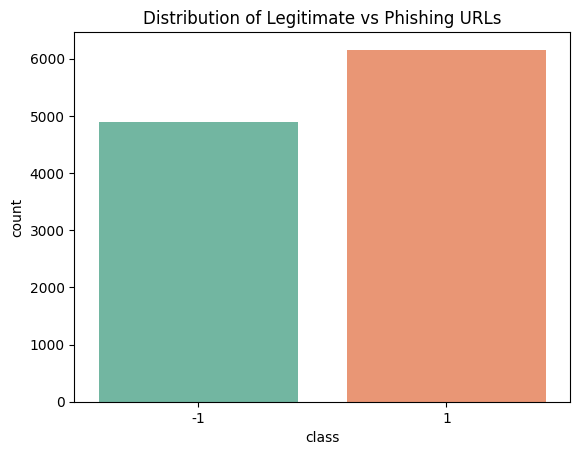

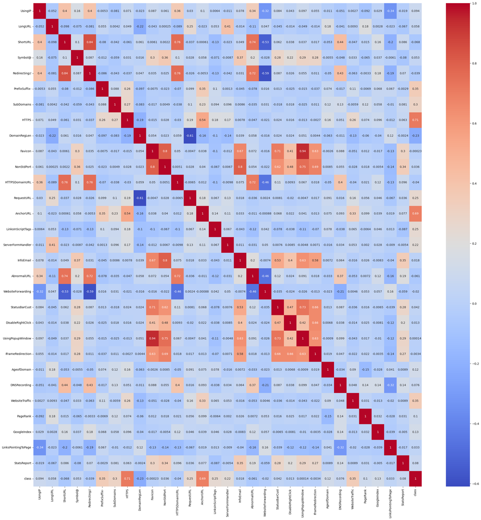

## Feature Importance (Based on Classification)

#### Visualization: Bar chart

#### Purpose: Visualize which features are most important for distinguishing between phishing and legitimate URLs, using a classification model.

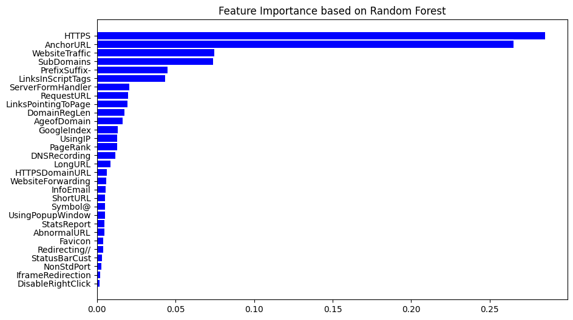

## Boxplots for Numerical Features

#### Visualization: Boxplots

#### Purpose: Examine the distribution of key numerical features (like WebsiteTraffic, DomainRegLen) across legitimate and phishing URLs.

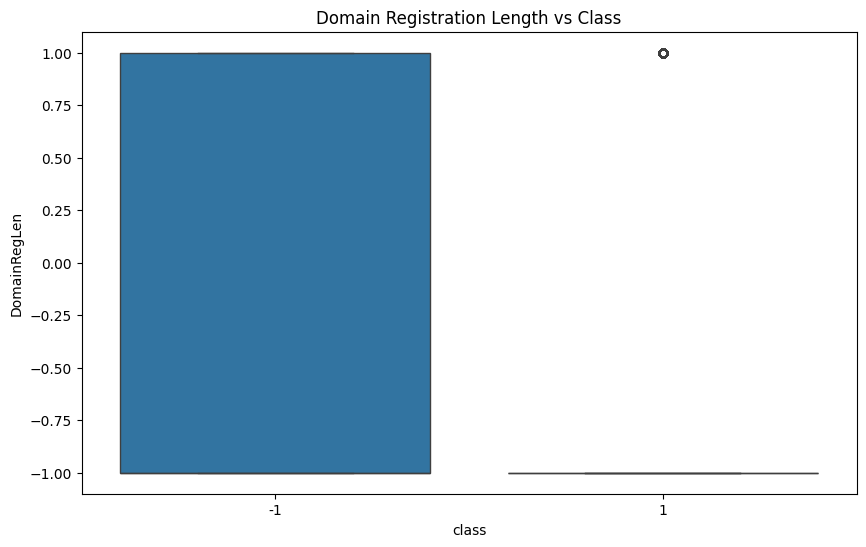

## Visualization: Boxplot

#### Purpose: Analyze how website traffic differs between phishing and legitimate sites.

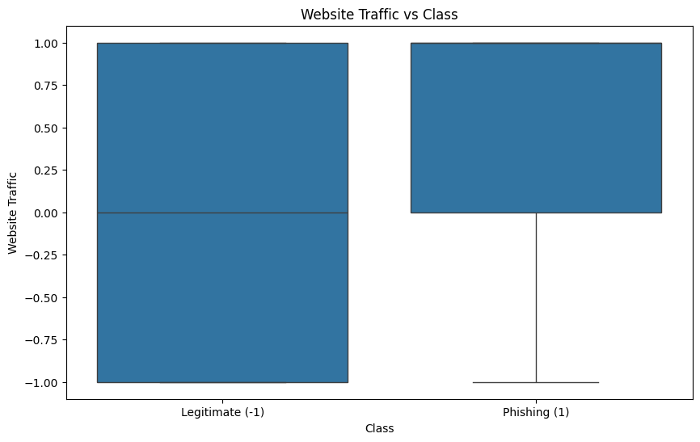

## Count of Short URLs vs. Long URLs

#### Visualization: Bar chart

#### Purpose: Compare the frequency of short URLs and long URLs in phishing and legitimate websites.

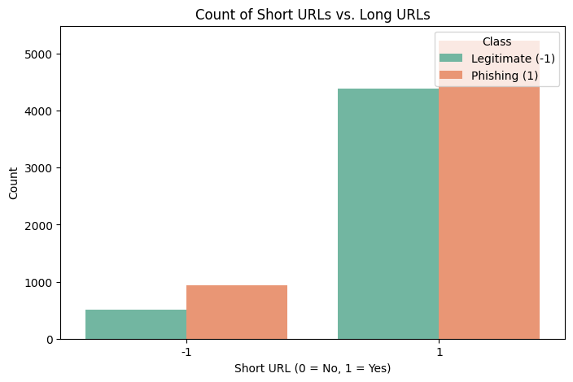

## Feature Distributions for Phishing vs. Legitimate

#### Visualization: Overlay histograms

#### Purpose: Show the distributions of key features for both classes side by side for comparison.

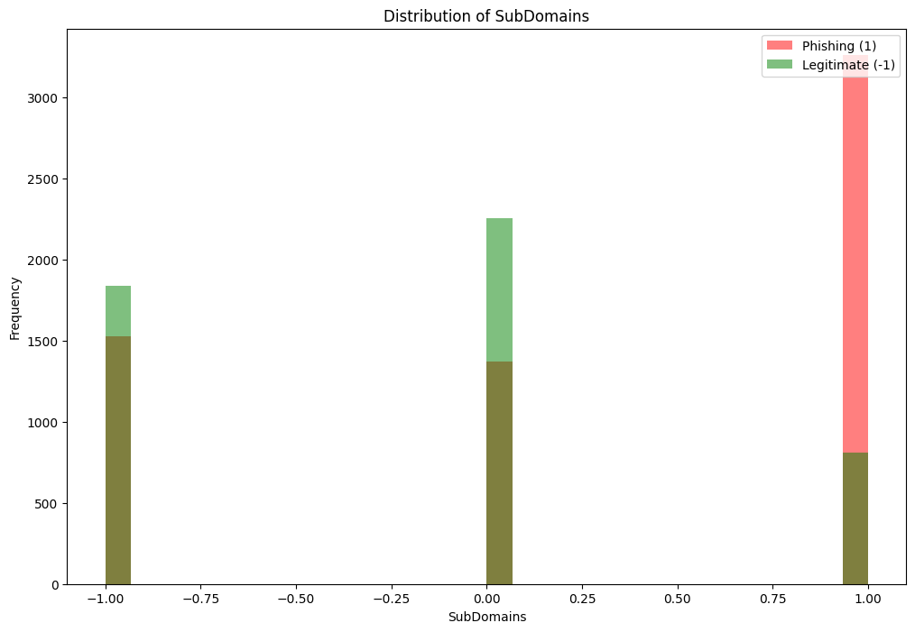

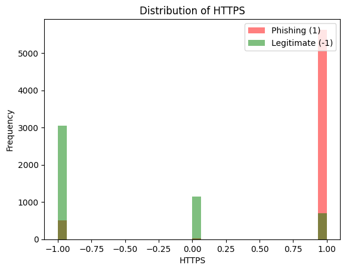

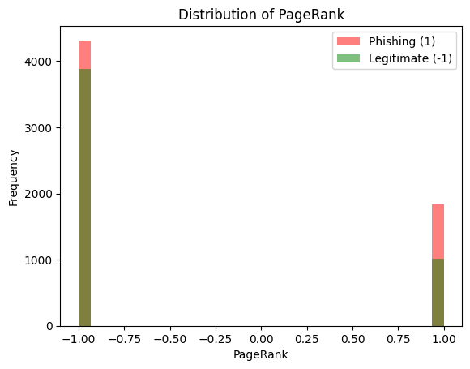

## Visualization: Pairplot (with KDE)

#### Purpose: Visualize the distribution and relationships of multiple features simultaneously for phishing and legitimate URLs.

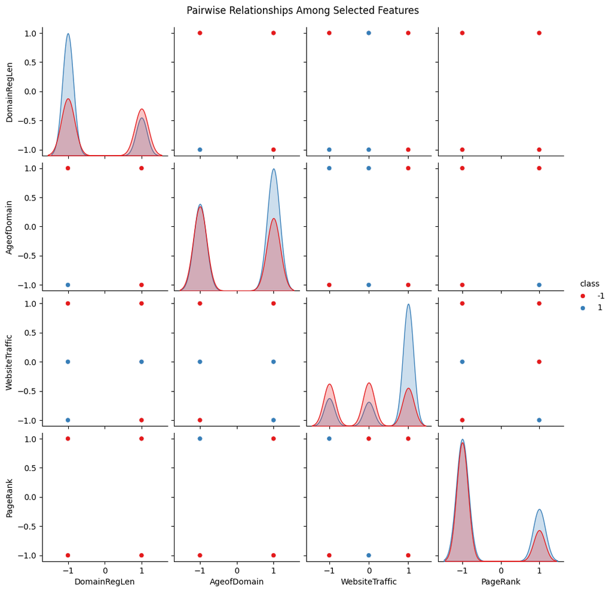

#### Visualization: Scatter plot

#### Purpose: Explore the relationship between website traffic and class label

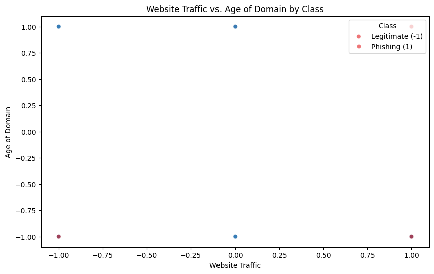

#### Purpose: Examine how many phishing tactics are present in each class by summing certain features (like UsingPopupWindow, IframeRedirection, etc.).

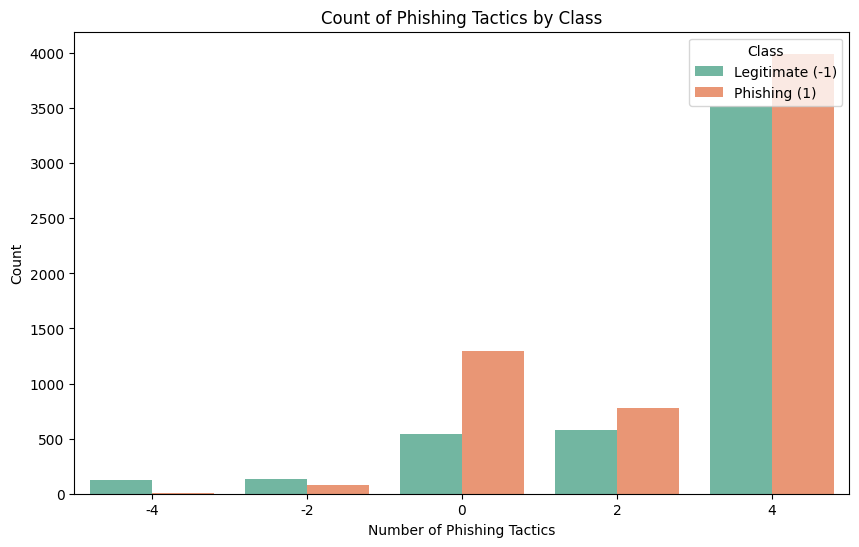

## 4. Splitting the Data:

The data is split into train & test sets, 80-20 split.

## K-Nearest Neighbors : Classifier

K-Nearest Neighbour is one of the simplest Machine Learning algorithms based on Supervised Learning technique. K-NN algorithm assumes the similarity between the new case/data and available cases and put the new case into the category that is most similar to the available categories.

```
KNeighborsClassifier(n_neighbors=1)
```

[output not shown]

```python
#computing the classification report of the model

print(metrics.classification_report(y_test, y_test_knn))
```

```
              precision    recall  f1-score   support

          -1       0.95      0.95      0.95       976
           1       0.96      0.96      0.96      1235

    accuracy                           0.96      2211
   macro avg       0.96      0.96      0.96      2211
weighted avg       0.96      0.96      0.96      2211
```

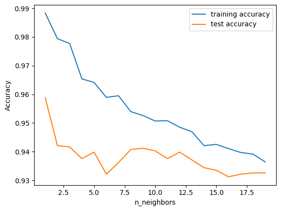

```python
training_accuracy = []
test_accuracy = []
# try max_depth from 1 to 20
depth = range(1,20)
for n in depth:
    knn = KNeighborsClassifier(n_neighbors=n)

    knn.fit(X_train, y_train)
    # record training set accuracy
    training_accuracy.append(knn.score(X_train, y_train))
    # record generalization accuracy
    test_accuracy.append(knn.score(X_test, y_test))


#plotting the training & testing accuracy for n_estimators from 1 to 20
plt.plot(depth, training_accuracy, label="training accuracy")
plt.plot(depth, test_accuracy, label="test accuracy")
plt.ylabel("Accuracy")
plt.xlabel("n_neighbors")
plt.legend()
```

## Support Vector Machine : Classifier

Support Vector Machine or SVM is one of the most popular Supervised Learning algorithms, which is used for Classification as well as Regression problems. The goal of the SVM algorithm is to create the best line or decision boundary that can segregate n-dimensional space into classes so that we can easily put the new data point in the correct category in the future.

```python
# Support Vector Classifier model
from sklearn.svm import SVC
from sklearn.model_selection import GridSearchCV

# defining parameter range
param_grid = {'gamma': [0.1],'kernel': ['rbf','linear']}

svc = GridSearchCV(SVC(), param_grid)

# fitting the model for grid search
svc.fit(X_train, y_train)
```

```
GridSearchCV(estimator=SVC(),
             param_grid={'gamma': [0.1], 'kernel': ['rbf', 'linear']})
```

```python
#predicting the target value from the model for the samples
y_train_svc = svc.predict(X_train)
y_test_svc = svc.predict(X_test)
```

```python
#computing the accuracy, f1_score, Recall, precision of the model performance

acc_train_svc = metrics.accuracy_score(y_train,y_train_svc)
acc_test_svc = metrics.accuracy_score(y_test,y_test_svc)
print("Support Vector Machine : Accuracy on training Data: {:.3f}".format(acc_train_svc))
print("Support Vector Machine : Accuracy on test Data: {:.3f}".format(acc_test_svc))
print()

f1_score_train_svc = metrics.f1_score(y_train,y_train_svc)
f1_score_test_svc = metrics.f1_score(y_test,y_test_svc)
print("Support Vector Machine : f1_score on training Data: {:.3f}".format(f1_score_train_svc))
print("Support Vector Machine : f1_score on test Data: {:.3f}".format(f1_score_test_svc))
print()

recall_score_train_svc = metrics.recall_score(y_train,y_train_svc)
recall_score_test_svc = metrics.recall_score(y_test,y_test_svc)
print("Support Vector Machine : Recall on training Data: {:.3f}".format(recall_score_train_svc))
print("Support Vector Machine : Recall on test Data: {:.3f}".format(recall_score_test_svc))
print()

precision_score_train_svc = metrics.precision_score(y_train,y_train_svc)
precision_score_test_svc = metrics.precision_score(y_test,y_test_svc)
print("Support Vector Machine : precision on training Data: {:.3f}".format(precision_score_train_svc))
print("Support Vector Machine : precision on test Data: {:.3f}".format(precision_score_test_svc))
```

```
Support Vector Machine : Accuracy on training Data: 0.969
Support Vector Machine : Accuracy on test Data: 0.964

Support Vector Machine : f1_score on training Data: 0.973
Support Vector Machine : f1_score on test Data: 0.968

Support Vector Machine : Recall on training Data: 0.980
Support Vector Machine : Recall on test Data: 0.980

Support Vector Machine : precision on training Data: 0.965
Support Vector Machine : precision on test Data: 0.957
```

```python
#computing the classification report of the model

print(metrics.classification_report(y_test, y_test_svc))
```

```
              precision    recall  f1-score   support

          -1       0.97      0.94      0.96       976
           1       0.96      0.98      0.97      1235

    accuracy                           0.96      2211
   macro avg       0.97      0.96      0.96      2211
weighted avg       0.96      0.96      0.96      2211
```

## Naive Bayes : Classifier

Naïve Bayes algorithm is a supervised learning algorithm, which is based on Bayes theorem and used for solving classification problems.It is mainly used in text, image classification that includes a high-dimensional training dataset. Naïve Bayes Classifier is one of the simple and most effective Classification algorithms which helps in building the fast machine learning models that can make quick predictions.

```python
# Naive Bayes Classifier Model
from sklearn.naive_bayes import GaussianNB
from sklearn.pipeline import Pipeline

# instantiate the model
nb=  GaussianNB()

# fit the model
nb.fit(X_train,y_train)
```

```
GaussianNB()
```

```python
#predicting the target value from the model for the samples
y_train_nb = nb.predict(X_train)
y_test_nb = nb.predict(X_test)
```

```python
#computing the accuracy, f1_score, Recall, precision of the model performance

acc_train_nb = metrics.accuracy_score(y_train,y_train_nb)
acc_test_nb = metrics.accuracy_score(y_test,y_test_nb)
print("Naive Bayes Classifier : Accuracy on training Data: {:.3f}".format(acc_train_nb))
print("Naive Bayes Classifier : Accuracy on test Data: {:.3f}".format(acc_test_nb))
print()

f1_score_train_nb = metrics.f1_score(y_train,y_train_nb)
f1_score_test_nb = metrics.f1_score(y_test,y_test_nb)
print("Naive Bayes Classifier : f1_score on training Data: {:.3f}".format(f1_score_train_nb))
print("Naive Bayes Classifier : f1_score on test Data: {:.3f}".format(f1_score_test_nb))
print()

recall_score_train_nb = metrics.recall_score(y_train,y_train_nb)
recall_score_test_nb = metrics.recall_score(y_test,y_test_nb)
print("Naive Bayes Classifier : Recall on training Data: {:.3f}".format(recall_score_train_nb))
print("Naive Bayes Classifier : Recall on test Data: {:.3f}".format(recall_score_test_nb))
print()

precision_score_train_nb = metrics.precision_score(y_train,y_train_nb)
precision_score_test_nb = metrics.precision_score(y_test,y_test_nb)
print("Naive Bayes Classifier : precision on training Data: {:.3f}".format(precision_score_train_nb))
print("Naive Bayes Classifier : precision on test Data: {:.3f}".format(precision_score_test_nb))
```

```
Naive Bayes Classifier : Accuracy on training Data: 0.605
Naive Bayes Classifier : Accuracy on test Data: 0.605

Naive Bayes Classifier : f1_score on training Data: 0.451
Naive Bayes Classifier : f1_score on test Data: 0.454

Naive Bayes Classifier : Recall on training Data: 0.292
Naive Bayes Classifier : Recall on test Data: 0.294

Naive Bayes Classifier : precision on training Data: 0.997
Naive Bayes Classifier : precision on test Data: 0.995
```

```python
#computing the classification report of the model

print(metrics.classification_report(y_test, y_test_svc))
```

```
              precision    recall  f1-score   support

          -1       0.97      0.94      0.96       976
           1       0.96      0.98      0.97      1235

    accuracy                           0.96      2211
   macro avg       0.97      0.96      0.96      2211
weighted avg       0.96      0.96      0.96      2211
```

## Decision Trees : Classifier

Decision Tree is a Supervised learning technique that can be used for both classification and Regression problems, but mostly it is preferred for solving Classification problems. It is a tree-structured classifier, where internal nodes represent the features of a dataset, branches represent the decision rules and each leaf node represents the outcome.

```python
# Decision Tree Classifier model
from sklearn.tree import DecisionTreeClassifier

# instantiate the model
tree = DecisionTreeClassifier(max_depth=30)

# fit the model
tree.fit(X_train, y_train)
```

```
DecisionTreeClassifier(max_depth=30)
```

```python
#predicting the target value from the model for the samples

y_train_tree = tree.predict(X_train)
y_test_tree = tree.predict(X_test)
```

```python
#computing the accuracy, f1_score, Recall, precision of the model performance

acc_train_tree = metrics.accuracy_score(y_train,y_train_tree)
acc_test_tree = metrics.accuracy_score(y_test,y_test_tree)
print("Decision Tree : Accuracy on training Data: {:.3f}".format(acc_train_tree))
print("Decision Tree : Accuracy on test Data: {:.3f}".format(acc_test_tree))
print()

f1_score_train_tree = metrics.f1_score(y_train,y_train_tree)
f1_score_test_tree = metrics.f1_score(y_test,y_test_tree)
print("Decision Tree : f1_score on training Data: {:.3f}".format(f1_score_train_tree))
print("Decision Tree : f1_score on test Data: {:.3f}".format(f1_score_test_tree))
print()

recall_score_train_tree = metrics.recall_score(y_train,y_train_tree)
recall_score_test_tree = metrics.recall_score(y_test,y_test_tree)
print("Decision Tree : Recall on training Data: {:.3f}".format(recall_score_train_tree))
print("Decision Tree : Recall on test Data: {:.3f}".format(recall_score_test_tree))
print()

precision_score_train_tree = metrics.precision_score(y_train,y_train_tree)
precision_score_test_tree = metrics.precision_score(y_test,y_test_tree)
print("Decision Tree : precision on training Data: {:.3f}".format(precision_score_train_tree))
print("Decision Tree : precision on test Data: {:.3f}".format(precision_score_test_tree))
```

```
Decision Tree : Accuracy on training Data: 0.991
Decision Tree : Accuracy on test Data: 0.958

Decision Tree : f1_score on training Data: 0.992
Decision Tree : f1_score on test Data: 0.963

Decision Tree : Recall on training Data: 0.991
Decision Tree : Recall on test Data: 0.960

Decision Tree : precision on training Data: 0.993
Decision Tree : precision on test Data: 0.965
```

```python
#computing the classification report of the model

print(metrics.classification_report(y_test, y_test_tree))
```

```
              precision    recall  f1-score   support

          -1       0.95      0.96      0.95       976
           1       0.97      0.96      0.96      1235

    accuracy                           0.96      2211
   macro avg       0.96      0.96      0.96      2211
weighted avg       0.96      0.96      0.96      2211
```

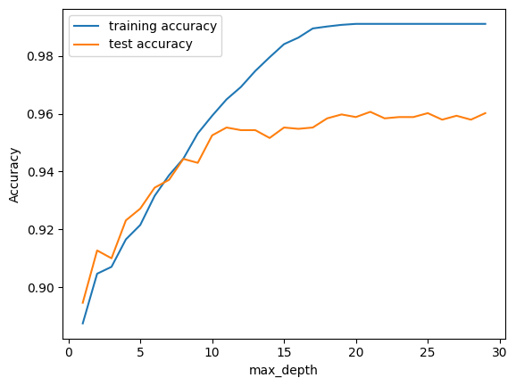

```python
training_accuracy = []
test_accuracy = []
# try max_depth from 1 to 30
depth = range(1,30)
for n in depth:
    tree_test = DecisionTreeClassifier(max_depth=n)

    tree_test.fit(X_train, y_train)
    # record training set accuracy
    training_accuracy.append(tree_test.score(X_train, y_train))
    # record generalization accuracy
    test_accuracy.append(tree_test.score(X_test, y_test))


#plotting the training & testing accuracy for max_depth from 1 to 30
plt.plot(depth, training_accuracy, label="training accuracy")
plt.plot(depth, test_accuracy, label="test accuracy")
plt.ylabel("Accuracy")
plt.xlabel("max_depth")
plt.legend();
```

```python
import matplotlib.pyplot as plt
import numpy as np
from sklearn.metrics import confusion_matrix, accuracy_score, f1_score
import seaborn as sns

def plot_confusion_matrix(y_true, y_pred, model_name):
    cm = confusion_matrix(y_true, y_pred)
    plt.figure(figsize=(6,4))
    sns.heatmap(cm, annot=True, fmt="d", cmap="Blues")
    plt.title(f'Confusion Matrix for {model_name}')
    plt.ylabel('Actual Label')
    plt.xlabel('Predicted Label')
    plt.show()

# Dummy lists for storing accuracies
train_accuracies = []
test_accuracies = []

# Function to plot training vs testing accuracy
def plot_training_vs_testing(train_accuracies, test_accuracies, model_name):
    epochs = np.arange(1, len(train_accuracies)+1)
    plt.figure(figsize=(8,6))
    plt.plot(epochs, train_accuracies, label='Training Accuracy')
    plt.plot(epochs, test_accuracies, label='Testing Accuracy')
    plt.title(f'Training vs Testing Accuracy for {model_name}')
    plt.xlabel('Iterations')
    plt.ylabel('Accuracy')
    plt.legend()
    plt.show()
```

### Bagging (Bootstrap Aggregation):

This technique involves training multiple instances of the same algorithm on different subsets of the data.

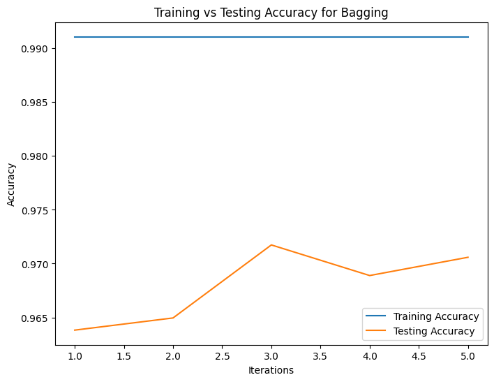

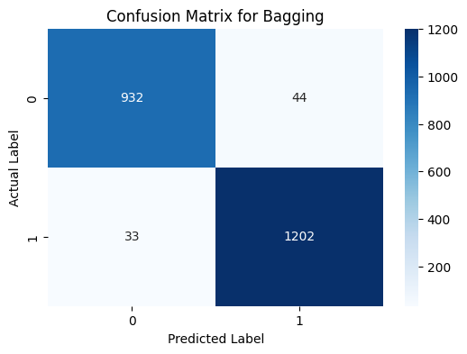

```python
from sklearn.model_selection import cross_val_score
from sklearn.ensemble import BaggingClassifier
from sklearn.tree import DecisionTreeClassifier

# Initialize the lists to store accuracies for plotting
train_accuracies = []
test_accuracies = []

# Example for Bagging with Cross-Validation
bagging_model = BaggingClassifier(estimator=DecisionTreeClassifier(), n_estimators=100, random_state=42)

# Perform cross-validation to get training and test accuracy scores
# Using 'cv=5' for 5-fold cross-validation
cv_scores = cross_val_score(bagging_model, X_train, y_train, cv=5)

# Record the cross-validation scores (this gives testing accuracies for each fold)
test_accuracies = list(cv_scores)

# Since cross_val_score only provides test accuracy, you might approximate train accuracy with out-of-fold errors
bagging_model.fit(X_train, y_train)
train_accuracy = bagging_model.score(X_train, y_train)
train_accuracies = [train_accuracy] * len(test_accuracies)  # Replicate train accuracy for each fold (for plotting)

# Plot the accuracy graphs
plot_training_vs_testing(train_accuracies, test_accuracies, "Bagging")

# Make predictions on the test set and plot confusion matrix
bagging_predictions = bagging_model.predict(X_test)
plot_confusion_matrix(y_test, bagging_predictions, "Bagging")
```

### Stacking:

Stacking combines predictions from multiple models (base models) and uses a meta-model to make the final prediction.

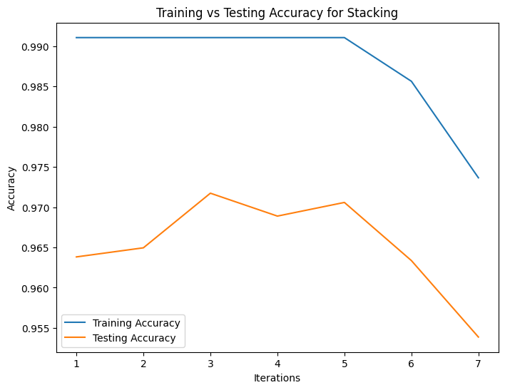

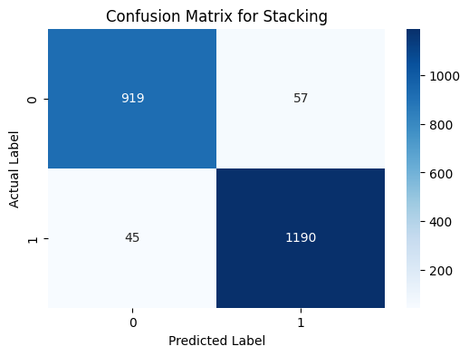

```python
from sklearn.ensemble import StackingClassifier
from sklearn.linear_model import LogisticRegression
from sklearn.tree import DecisionTreeClassifier
from sklearn.svm import SVC

estimators = [
    ('dt', DecisionTreeClassifier()),
    ('svc', SVC(probability=True))
]

# Define the StackingClassifier with a tree-based meta-model that supports feature_importances_
stacking_model = StackingClassifier(
    estimators=estimators,
    final_estimator=RandomForestClassifier(n_estimators=100, random_state=42)  # Tree-based meta-model
)

stacking_model.fit(X_train, y_train)

stacking_train_accuracy = accuracy_score(y_train, stacking_model.predict(X_train))
stacking_test_accuracy = accuracy_score(y_test, stacking_model.predict(X_test))
stacking_predictions = stacking_model.predict(X_test)

train_accuracies.append(stacking_train_accuracy)
test_accuracies.append(stacking_test_accuracy)

plot_training_vs_testing(train_accuracies, test_accuracies, "Stacking")
plot_confusion_matrix(y_test, stacking_predictions, "Stacking")
```

```python
import joblib

joblib.dump(stacking_model, 'stacking_model.joblib')
```

```
['stacking_model.joblib']
```